[figure not shown]

Prof. Carlos Andrés Ferrero

# Mineração de Dados

## Introdução à Mineração de Dados

# Conteúdo

- Processo de Descoberta de Conhecimento
- Aprendizado Supervisionado e Não-supervisionado
- Paradigmas de Aprendizado

# Introdução

**Número de Usuários na Internet**

- A quantidade de usuários na Internet no mundo pasou de 15 milhões em 1995 para 2,8 bilhões em 2013-2014 (CASTRO e FERRERRI, 2016)
- Alguns dados dos últimos 12 anos mostram o crescimento

[figure not shown]

- Em julho de 2018 esse número foi para 4 bilhões (STATISTA, 2018)

**Conteúdo no Wikipedia**

- A quantidade de conteúdo produzida no Wikipedia é enorme
- Em 2018 existem 5,5 milhões de artigos (apenas em Inglês)
- São produzidos cerca de 500 novos artígos por dia

[figure not shown]

By HenkvD - Own work, [CC BY-SA 3.0](https://creativecommons.org/licenses/by-sa/3.0), [Link](https://commons.wikimedia.org/w/index.php?curid=5702715)

**Buscas no Google**

- O Google processa cerca de 3,5 bilhões de buscas por dia (3,500,000,000)
- E cerca de 1,2 trilhões de buscas por ano (1,200,000,000,000)

[figure not shown]

Fonte: [Internet Livestats](http://www.internetlivestats.com/google-search-statistics/#sources)

- Entre 15 a 20% dessas buscas nunca foram feitas antes.

**Outras Estatísticas**

- São escritos mais de 500 milhões de tuítes por dia
- São vistos mais de 200 milhões de horas de vídeo no Youtube por dia
- No Facebook são criado 5 perfís por segundo e existem cerca de 83 milhões de *fake profiles* (ZAFORIA.COM)
- ...

**O que isto tem a ver com Mineração de Dados?**

- A produção de dados pelos usuários de Internet é gigante
- O Google utiliza (e cria) técnicas de mineração de dados, como Recuperação de Informação (*Information Retrieval*) para recuperar resultados das nossas consultas. Isto é mais do que uma consulta SQL.
- Com os dados do Twitter é possível ver quais são os *hot topics* nas diferentes regiões do mundo e inferir diferentes sentimentos dos usuários (ou grupos de usuários) usando técnicas de mineração de textos (*text mining*), chamada de análise sentimento (*sentiment analysis*)
- O Facebook usa mineração de dados para aprender sobre *fake profiles* e poder dar um grau de probabilidade de que um perfil de facebook trata-se de um *fake*. A classificação é um exemplo de técnica utilizada para esse fim.

## Áreas de Conhecimento envolvidas

- Visualização
- Estatística
- Matemática
- Engenharia
- Inteligência Artificial
- Banco de Dados
- Sistemas de Informação
- ...
- Do ponto de vista de um *data miner* em geral não precisa conhecer todas essas áreas do conhecimento profundamente antes de começar a prática de minerar dados, mas precisamos ter uma ideia dessas disciplinas para poder aprender com a experiência.
- Por exemplo, utilizar média e desvio padrão, dois temas fundamentais da Estatística, é vital para analisar dados, para entender a precisão de um *preditor*, entre outros.
- Mais atualmente, estamos escutando os termos de *Data Science* e *Data Scientist*, os quais demonstram claramente a importancia da Análise de Dados de uma forma geral no contexto de *Big Data*.
- Esses termos podem ser entendidos como uma evolução de data mining, onde procura-se analisar dados em diferentes formatos (convencionais, texto, imagens, temporais, entre outros) e, preferencialmente, de maneira conjunta, para extrair novas informações e conhecimentos, que sejam úteis para a sociedade.

## Dados, Informação e Conhecimento

Uma visão prática (CASTRO e FERRARI, 2016):

- Dados
  - 1000 milibares
  - 5,1 m/s; 95 graus
  - 30 graus centígrados
  - poucas
  - 1000 metros
- Informação
  - Pressão atmosférica = 1000 milibares
  - Velocidade e direção do vento = 5,1 m/s; 95 graus
  - Temperatura do ar = 30 graus centígrados
  - Nuvens = poucas
  - Visibilidade = 1000 mts
- Conhecimento
  - A probabilidade de chuva é baixa, portanto, posso ir à praia
- Definições:
  - **Dado**: símbolos e signos não estruturados, como os valores em tabelas e documentos
  - **Informação**: consistem nos dados interpretados, agregando significado e utilidade aos dados
  - **Conhecimento**: é algo que permite auxiliar em processos de tomada de decisão

## Processo de Descoberta de Conhecimento em Bases de Dados

- Também chamado de KDD (*Knowledge Discovery in Databases*), foi proposto por Piatetski-Shapiro em 1989
- Esse processo tem como principal objetivo extrair padrões intrínsecos nos dados e apresentá-los de forma a facilitar a sua assimilação como conhecimento, bem como da utilização para outros fins

### Etapas do Processo de Descoberta de Conhecimento (KDD)

[figure not shown]

### Pré-processamento

- Visa preparar os dados para uma análise eficiente e eficaz
- Algumas tarefas de pré-processamento:
  - Limpeza (remoção de ruídos e dados inconsistentes)
  - Integração (combinação de dados obtidos a partir de múltiplas fontes)
  - Seleção de Dados ou Redução (escolha dos dados relevantes para análise)
  - Transformação (transformação dos dados para um formato adequado para análise)

### Mineração de Dados ou Extração de Padrões

- Aplicação de algoritmos capazes de extrair padrões e/ou informações e conhecimento relevantes a partir dos dados pré-processados
- Algumas tarefas de mineração:
  - Análise descritiva estatística
  - Agrupamento
  - Modelos de Predição (classificação e regressão)
  - Associação (extração de regras de associação)
  - Detecção de Anomalias

### Pós-procesamento ou avaliação de modelos

- Avaliação da qualidade dos modelos ou conhecimento extraído na etapa de Mineração de Dados
- Algumas tarefas de pós-processamento:
  - Verificar a precisão dos modelos construídos em novos dados
  - Identificar conhecimentos verdadeiros e conhecimentos triviais
  - Identificar problemas no pré-processamento ou mineração que precisem ser modificados para a melhoría do processo de descoberta de conhecimento

### Um exemplo prático

- Estudo de um conjunto de dados de flores (*iris*)
- O dataset está constutuído de 150 flores (50 flores de cada espécie). Cada flor está representada por 4 atributos numéricos:
  - Sepal-length
  - Sepal-width
  - Petal-length
  - Petal-width
- As espécies ou *classes* são: *iris-versicolor*, *iris-virginica*, *iris-setosa*. Um exemplo dessas flores está nesta imagem:

[figure not shown]

Fonte: http://suruchifialoke.com/2016-10-13-machine-learning-tutorial-iris-classification/

**Uma visão geral do conjunto de dados coletado**

```r
head(dt.iris.text)
```

| Exemplos |
| --- |
| Sepal.Length 5.1, Sepal.Width 3.5, Petal.Length 1.4, Petal.Width 0.2, and Species setosa |
| Sepal.Length 4.9, Sepal.Width 3, Petal.Length 1.4, Petal.Width 0.2, and Species setosa |
| Sepal.Length 4.7, Sepal.Width 3.2, Petal.Length 1.3, Petal.Width 0.2, and Species setosa |
| Sepal.Length 4.6, Sepal.Width 3.1, Petal.Length 1.5, Petal.Width 0.2, and Species setosa |
| Sepal.Length 5, Sepal.Width 3.6, Petal.Length 1.4, Petal.Width 0.2, and Species setosa |
| Sepal.Length 5.4, Sepal.Width 3.9, Petal.Length 1.7, Petal.Width 0.4, and Species setosa |

**Pré-processamento**

Extração dos dados do texto para um formato atributo-valor. Esse formato é representado por uma tabela onde as *linhas* são as instâncias (ou exemplos) de flores e as *colunas* os atributos das flores. Definimos os primeiros 4 atributos como numéricos e o atributo *Species* como categórico.

```r
head(dt.iris, 10)
```

| Sepal.Length | Sepal.Width | Petal.Length | Petal.Width | Species |
| --- | --- | --- | --- | --- |
| 5.1 | 3.5 | 1.4 | 0.2 | setosa |
| 4.9 | 3.0 | 1.4 | 0.2 | setosa |
| 4.7 | 3.2 | 1.3 | 0.2 | setosa |
| 4.6 | 3.1 | 1.5 | 0.2 | setosa |
| 5.0 | 3.6 | 1.4 | 0.2 | setosa |
| 5.4 | 3.9 | 1.7 | 0.4 | setosa |
| 4.6 | 3.4 | 1.4 | 0.3 | setosa |
| 5.0 | 3.4 | 1.5 | 0.2 | setosa |
| 4.4 | 2.9 | 1.4 | 0.2 | setosa |
| 4.9 | 3.1 | 1.5 | 0.1 | setosa |

**Descrição de dados**

```r
dt.iris.melt[,.(mean = mean(value), sd = sd(value)), .(variable) ]
```

| variable | mean | sd |
| --- | --- | --- |
| Sepal.Length | 5.843333 | 0.8280661 |
| Sepal.Width | 3.057333 | 0.4358663 |
| Petal.Length | 3.758000 | 1.7652982 |
| Petal.Width | 1.199333 | 0.7622377 |

**Visualização de dados**

- *Análise da distribuição dos valores dos atributo por classe*

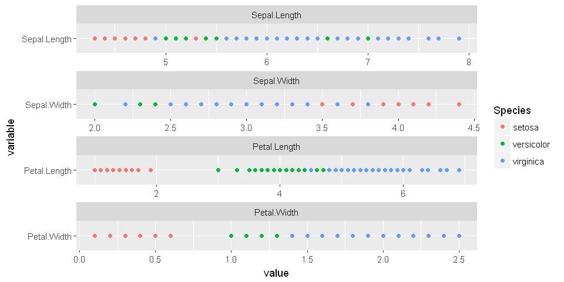

```r
ggplot(data=dt.iris.melt, aes(y=variable, x=value, color=Species)) + geom_point() + facet_wrap(~variable, ncol=1, scales = "free")
```

- *Diagrama de Caixas dos atributos por classe*

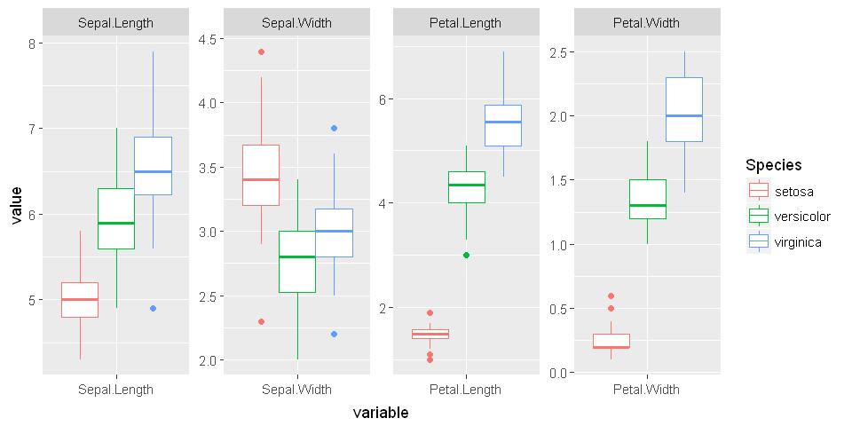

```r
ggplot(data=dt.iris.melt, aes(x=variable, y=value, color=Species)) + geom_boxplot() + facet_wrap(~variable, ncol=4, scales = "free")
```

- Interação dos atributos *Sepal.Length* and *Sepal.Width* por *Species*

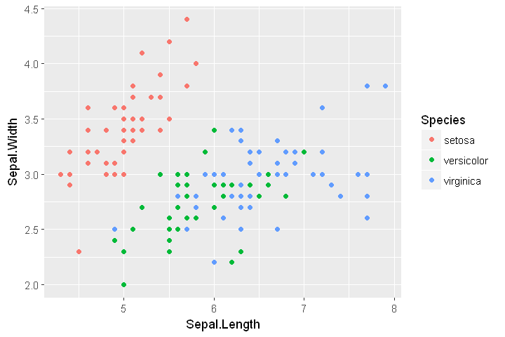

```r
ggplot(data=dt.iris, aes(x=Sepal.Length, y= Sepal.Width, color = Species)) + geom_point()
```

- Interação dos atributos *Petal.Length* and *Petal.Width* por *Species*

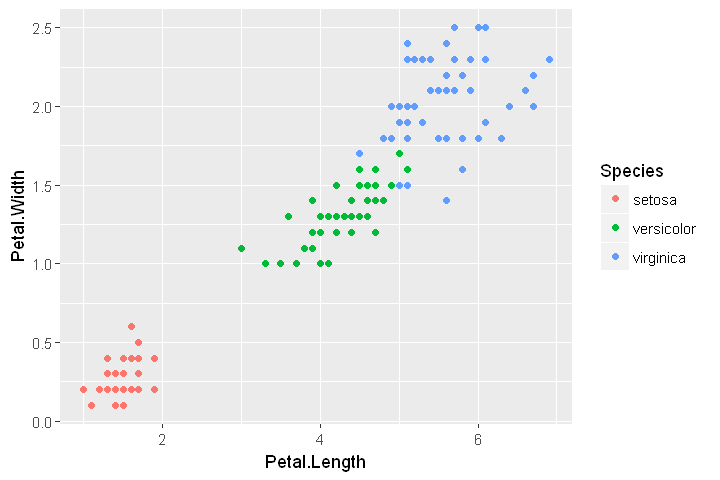

```r
ggplot(data=dt.iris, aes(x=Petal.Length, y= Petal.Width, color = Species)) + geom_point()
```

**Mineração de Dados**

*Objetivo*: criar uma função que utilize os 4 atributos numéricos para determinar a espécie da flor.

Se conseguirmos encontrar uma boa função para determinar a espécie, podemos usar essa função para descobrir a espécie de novas flores.

```r
(model <- J48(data = dt.iris, Species ~. ) )
```

```
J48 pruned tree
------------------

Petal.Width <= 0.6: setosa (50.0)
Petal.Width > 0.6
|   Petal.Width <= 1.7
|   |   Petal.Length <= 4.9: versicolor (48.0/1.0)
|   |   Petal.Length > 4.9
|   |   |   Petal.Width <= 1.5: virginica (3.0)
|   |   |   Petal.Width > 1.5: versicolor (3.0/1.0)
|   Petal.Width > 1.7: virginica (46.0/1.0)

Number of Leaves  : 	5

Size of the tree : 	9
```

**Avaliação de Modelos**

Verificar qual foi a precisão do modelo construído com os dados que temos

```r
summary(model)
```

```
=== Summary ===

Correctly Classified Instances         147               98      %
Incorrectly Classified Instances         3                2      %
Kappa statistic                          0.97
Mean absolute error                      0.0233
Root mean squared error                  0.108
Relative absolute error                  5.2482 %
Root relative squared error             22.9089 %
Total Number of Instances              150

=== Confusion Matrix ===

  a  b  c   <-- classified as
 50  0  0 |  a = setosa
  0 49  1 |  b = versicolor
  0  2 48 |  c = virginica
```

# Aprendizado Supervisionado e Não-Supervisionado

As técnicas para aprender modelos a partir de dados são classificadas de acordo com o tipo de aprendizado em:

- **Aprendizado Supervisionado**
- **Aprendizado Não-supervisinado**
- **Aprendizado Semi-Supervisionado**

## Aprendizado Supervisionado

No aprendizado supervisionado os exemplos estão constituídos por atributos, onde um desses atributos é *classe*

O atributo *classe* permite orientar o processo de aprendizando para ajustar um modelo aos dados

| Exemplo | Atributo 1 | Atributo 2 | ... | Atributo m | Atributo classe |
| --- | --- | --- | --- | --- | --- |
| $e_1$ | $x_{1,1}$ | $x_{1,2}$ | ... | $x_{1,m}$ | $y_1$ |
| $e_2$ | $x_{2,1}$ | $x_{2,2}$ | ... | $x_{2,m}$ | $y_2$ |
| ... | ... | ... | ... | ... | ... |
| $e_n$ | $x_{n,1}$ | $x_{n,2}$ | ... | $x_{n,m}$ | $y_n$ |

Neste aprendizado o objetivo consiste em encontrar uma função $f(X) = \hat{y}$, em que, dado os valores dos $m$ atributos, estime $y$.

As tarefas de interesse do aprendizado supervisionado são preditivas e definidas por:

- **Classificação**: quando o valor da *classe* é um valor categórico (ou discreto)
- **Regressão**: quando o valor da *classe* é um valor numérico.

## Aprendizado Não-superivsionado

No aprendizado não-supervisionado os exemplos estão constituídos por atributos, mas não há um atrbiuto *classe*

Isso indica que não tem como orientar o processo de aprendizado tentando acertar algum valor de atributo específico

| Exemplo | Atributo 1 | Atributo 2 | ... | Atributo m |
| --- | --- | --- | --- | --- |
| $e_1$ | $x_{1,1}$ | $x_{1,2}$ | ... | $x_{1,m}$ |
| $e_2$ | $x_{2,1}$ | $x_{2,2}$ | ... | $x_{2,m}$ |
| ... | ... | ... | ... | ... |
| $e_n$ | $x_{n,1}$ | $x_{n,2}$ | ... | $x_{n,m}$ |

Neste tipo de aprendizado tentamos encontrar grupos de dados que apresentem comportamento similar

As tarefas de interesse dentro do aprendizado não-supervisionado são:

- **Agrupamentos**: agrupar exemplos de acordo com algum critério de distância ou similaridade
- **Extração de regras de associação**: encontrar relaçoes entre atributos e os valores dos atributos

## Tarefas de Mineração de Dados

As principais tarefas de mineração são:

- Predição (seja classificação ou regressão)
- Agrupamento
- Associação

A seguinte figura temos a relação dessas tarefas em um conjunto de dados convencional:

[figure not shown]

<sub>Fonte: Silva, L. A., Peres, S. M., & Boscarioli, C. (2017). **Introdução à mineração de dados: com aplicações em R**. Elsevier Brasil</sub>

## Aprendizado Semi-Supervisionado

- No aprendizado semi-supervisionado apenas alguns exemplos do conjunto de dados possuem o valor do atributo *classe*.
- Muitas vezes é muito caro classificar elementos. Alguns exemplos:
  - Transcrever segmentos de áudio
  - Identificar observações de experimentos físicos
  - Identificar os rostros de fotos do Facebook manualmente
- Nestas situações, com algumas instâncias rotuladas (exemplos classificados) é possível inferir os rótulos e classes de outras instâncias.

[figure not shown]

<sub>Fonte: Wang, F., & Zhang, C. (2007). **Robust self-tuning semi-supervised learning**. *Neurocomputing*, 70(16-18), 2931-2939.</sub>

# Paradigmas de Aprendizado

Alguns autores chamam de paradigmas os aprendizados supervisionado e não-supervisionado (CASTRO e FERRARI, 2016).

No entanto a literatura clássica divide os paradimgas de aprendizado da seguinte forma:

- Simbólico
- Baseado em Instância
- Estatístico
- Conexionista
- Genético

Uma ótima leitura sobre os pardigmas pode ser encontrada em:

- MONARD, Maria Carolina; BARANAUSKAS, José Augusto. **Conceitos sobre aprendizado de máquina**. Sistemas Inteligentes-Fundamentos e Aplicações, v. 1, n. 1, p. 32, 2003. Disponível em: http://dcm.ffclrp.usp.br/~augusto/publications/2003-sistemas-inteligentes-cap4.pdf